# Risk Factor Analysis

## Outcome Variable

**Outcome Variable:** co_occurence

## Predictor Variables

**Intervention Variable:** ever_swasted06

**Adjustment Set:**

- sex
- arm
- brthmon
- single
- hhwealth_quart
- W_mage
- W_mhtcm
- W_meducyrs
- W_feducyrs
- delta_brthmon
- delta_single
- delta_hhwealth_quart
- delta_W_mage
- delta_W_mhtcm
- delta_W_meducyrs
- delta_W_feducyrs

## Stratifying Variables

The analysis was stratified on these variable(s):

- studyid
- country

## Data Summary

| studyid | country | ever_swasted06 | co_occurence | n_cell | n |
| --- | --- | --- | --- | --- | --- |
| ki0047075b-MAL-ED | BANGLADESH | 0 | 0 | 194 | 221 |
| ki0047075b-MAL-ED | BANGLADESH | 0 | 1 | 12 | 221 |
| ki0047075b-MAL-ED | BANGLADESH | 1 | 0 | 13 | 221 |
| ki0047075b-MAL-ED | BANGLADESH | 1 | 1 | 2 | 221 |
| ki0047075b-MAL-ED | BRAZIL | 0 | 0 | 177 | 180 |
| ki0047075b-MAL-ED | BRAZIL | 0 | 1 | 1 | 180 |
| ki0047075b-MAL-ED | BRAZIL | 1 | 0 | 2 | 180 |
| ki0047075b-MAL-ED | BRAZIL | 1 | 1 | 0 | 180 |
| ki0047075b-MAL-ED | INDIA | 0 | 0 | 195 | 228 |
| ki0047075b-MAL-ED | INDIA | 0 | 1 | 12 | 228 |
| ki0047075b-MAL-ED | INDIA | 1 | 0 | 16 | 228 |
| ki0047075b-MAL-ED | INDIA | 1 | 1 | 5 | 228 |
| ki0047075b-MAL-ED | NEPAL | 0 | 0 | 218 | 229 |
| ki0047075b-MAL-ED | NEPAL | 0 | 1 | 4 | 229 |
| ki0047075b-MAL-ED | NEPAL | 1 | 0 | 7 | 229 |
| ki0047075b-MAL-ED | NEPAL | 1 | 1 | 0 | 229 |
| ki0047075b-MAL-ED | PERU | 0 | 0 | 215 | 222 |
| ki0047075b-MAL-ED | PERU | 0 | 1 | 6 | 222 |
| ki0047075b-MAL-ED | PERU | 1 | 0 | 1 | 222 |
| ki0047075b-MAL-ED | PERU | 1 | 1 | 0 | 222 |
| ki0047075b-MAL-ED | SOUTH AFRICA | 0 | 0 | 231 | 241 |
| ki0047075b-MAL-ED | SOUTH AFRICA | 0 | 1 | 3 | 241 |
| ki0047075b-MAL-ED | SOUTH AFRICA | 1 | 0 | 6 | 241 |
| ki0047075b-MAL-ED | SOUTH AFRICA | 1 | 1 | 1 | 241 |
| ki0047075b-MAL-ED | TANZANIA, UNITED REPUBLIC OF | 0 | 0 | 220 | 225 |
| ki0047075b-MAL-ED | TANZANIA, UNITED REPUBLIC OF | 0 | 1 | 1 | 225 |
| ki0047075b-MAL-ED | TANZANIA, UNITED REPUBLIC OF | 1 | 0 | 4 | 225 |
| ki0047075b-MAL-ED | TANZANIA, UNITED REPUBLIC OF | 1 | 1 | 0 | 225 |
| ki1000108-CMC-V-BCS-2002 | INDIA | 0 | 0 | 287 | 366 |
| ki1000108-CMC-V-BCS-2002 | INDIA | 0 | 1 | 11 | 366 |

[output cut: 78 more lines]

The following strata were considered:

- studyid: ki0047075b-MAL-ED, country: BANGLADESH
- studyid: ki0047075b-MAL-ED, country: BRAZIL
- studyid: ki0047075b-MAL-ED, country: INDIA
- studyid: ki0047075b-MAL-ED, country: NEPAL
- studyid: ki0047075b-MAL-ED, country: PERU
- studyid: ki0047075b-MAL-ED, country: SOUTH AFRICA
- studyid: ki0047075b-MAL-ED, country: TANZANIA, UNITED REPUBLIC OF
- studyid: ki1000108-CMC-V-BCS-2002, country: INDIA
- studyid: ki1000108-IRC, country: INDIA
- studyid: ki1000109-EE, country: PAKISTAN
- studyid: ki1000109-ResPak, country: PAKISTAN
- studyid: ki1000304b-SAS-CompFeed, country: INDIA
- studyid: ki1000304b-SAS-FoodSuppl, country: INDIA
- studyid: ki1017093-NIH-Birth, country: BANGLADESH
- studyid: ki1017093b-PROVIDE, country: BANGLADESH
- studyid: ki1017093c-NIH-Crypto, country: BANGLADESH
- studyid: ki1066203-TanzaniaChild2, country: TANZANIA, UNITED REPUBLIC OF
- studyid: ki1101329-Keneba, country: GAMBIA
- studyid: ki1113344-GMS-Nepal, country: NEPAL
- studyid: ki1114097-CMIN, country: BANGLADESH
- studyid: ki1114097-CONTENT, country: PERU
- studyid: ki1119695-PROBIT, country: BELARUS
- studyid: ki1126311-ZVITAMBO, country: ZIMBABWE
- studyid: ki1135781-COHORTS, country: GUATEMALA
- studyid: ki1135781-COHORTS, country: PHILIPPINES
- studyid: ki1148112-LCNI-5, country: MALAWI
- studyid: kiGH5241-JiVitA-4, country: BANGLADESH

### Dropped Strata

Some strata were dropped due to rare outcomes:

- studyid: ki0047075b-MAL-ED, country: BANGLADESH
- studyid: ki0047075b-MAL-ED, country: BRAZIL
- studyid: ki0047075b-MAL-ED, country: NEPAL
- studyid: ki0047075b-MAL-ED, country: PERU
- studyid: ki0047075b-MAL-ED, country: SOUTH AFRICA
- studyid: ki0047075b-MAL-ED, country: TANZANIA, UNITED REPUBLIC OF
- studyid: ki1000109-ResPak, country: PAKISTAN
- studyid: ki1017093b-PROVIDE, country: BANGLADESH
- studyid: ki1017093c-NIH-Crypto, country: BANGLADESH
- studyid: ki1066203-TanzaniaChild2, country: TANZANIA, UNITED REPUBLIC OF
- studyid: ki1114097-CMIN, country: BANGLADESH
- studyid: ki1114097-CONTENT, country: PERU
- studyid: ki1119695-PROBIT, country: BELARUS
- studyid: ki1135781-COHORTS, country: GUATEMALA
- studyid: ki1148112-LCNI-5, country: MALAWI

## Methods Detail

We’re interested in the causal parameters $E[Y_a]$ for all values of $a \in \mathcal{A}$. These parameters represent the mean outcome if, possibly contrary to fact, we intervened to set all units to have $A=a$. Under the randomization and positivity assumptions, these are identified by the statistical parameters $\psi_a=E_W[E_{Y|A,W}(Y|A=a,W)]$. In addition, we’re interested in the mean of $Y$, $E[Y]$ under no intervention (the observed mean). We will estimate these parameters by using SuperLearner to fit the relevant likelihood factors – $E_{Y|A,W}(Y|A=a,W)$ and $p(A=a|W)$, and then updating our likelihood fit using a joint TMLE.

For unadjusted analyses ($W=\{\}$), initial likelihoods were estimated using Lrnr_glm to estimate the simple $E(Y|A)$ and Lrnr_mean to estimate $p(A)$. For adjusted analyses, a small library containing Lrnr_glmnet, Lrnr_xgboost, and Lrnr_mean was used.

Having estimated these parameters, we will then use the delta method to estimate relative risks and attributable risks relative to a prespecified baseline level of $A$.

# Results Detail

## Results Plots

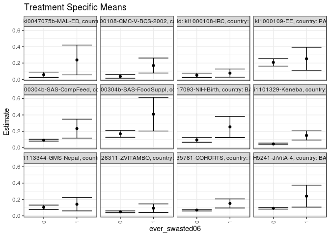

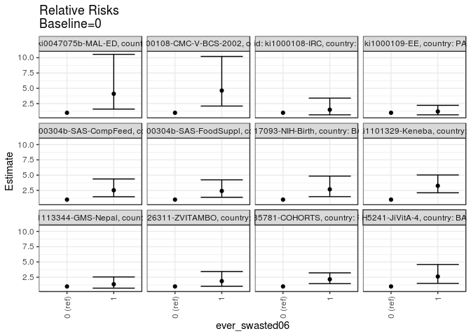

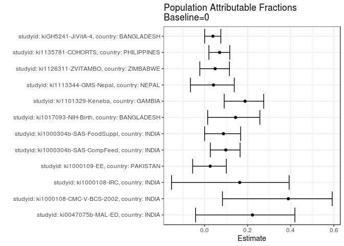

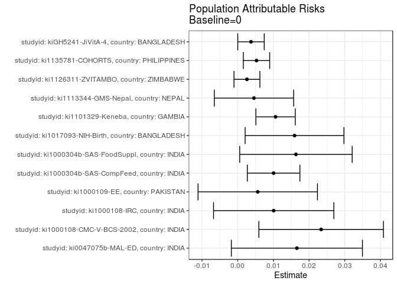

## Results Table

### Parameter: TSM

| studyid | country | intervention_level | baseline_level | estimate | ci_lower | ci_upper |
| --- | --- | --- | --- | --- | --- | --- |
| ki0047075b-MAL-ED | INDIA | 0 | NA | 0.0579710 | 0.0260663 | 0.0898757 |
| ki0047075b-MAL-ED | INDIA | 1 | NA | 0.2380952 | 0.0555298 | 0.4206607 |
| ki1000108-CMC-V-BCS-2002 | INDIA | 0 | NA | 0.0367270 | 0.0153800 | 0.0580741 |
| ki1000108-CMC-V-BCS-2002 | INDIA | 1 | NA | 0.1701313 | 0.0785081 | 0.2617544 |
| ki1000108-IRC | INDIA | 0 | NA | 0.0516452 | 0.0255088 | 0.0777817 |
| ki1000108-IRC | INDIA | 1 | NA | 0.0774811 | 0.0278960 | 0.1270663 |
| ki1000109-EE | PAKISTAN | 0 | NA | 0.2082503 | 0.1628471 | 0.2536535 |
| ki1000109-EE | PAKISTAN | 1 | NA | 0.2529880 | 0.1120381 | 0.3939378 |
| ki1000304b-SAS-CompFeed | INDIA | 0 | NA | 0.0918456 | 0.0804799 | 0.1032113 |
| ki1000304b-SAS-CompFeed | INDIA | 1 | NA | 0.2327006 | 0.1170186 | 0.3483826 |
| ki1000304b-SAS-FoodSuppl | INDIA | 0 | NA | 0.1694352 | 0.1269902 | 0.2118802 |
| ki1000304b-SAS-FoodSuppl | INDIA | 1 | NA | 0.4090909 | 0.2033217 | 0.6148601 |
| ki1017093-NIH-Birth | BANGLADESH | 0 | NA | 0.0944634 | 0.0662684 | 0.1226585 |
| ki1017093-NIH-Birth | BANGLADESH | 1 | NA | 0.2533922 | 0.1244053 | 0.3823791 |
| ki1101329-Keneba | GAMBIA | 0 | NA | 0.0457295 | 0.0355552 | 0.0559039 |
| ki1101329-Keneba | GAMBIA | 1 | NA | 0.1491371 | 0.0936735 | 0.2046006 |
| ki1113344-GMS-Nepal | NEPAL | 0 | NA | 0.1045319 | 0.0771030 | 0.1319608 |
| ki1113344-GMS-Nepal | NEPAL | 1 | NA | 0.1419347 | 0.0604636 | 0.2234058 |
| ki1126311-ZVITAMBO | ZIMBABWE | 0 | NA | 0.0497897 | 0.0390181 | 0.0605613 |
| ki1126311-ZVITAMBO | ZIMBABWE | 1 | NA | 0.0933847 | 0.0403993 | 0.1463702 |
| ki1135781-COHORTS | PHILIPPINES | 0 | NA | 0.0699203 | 0.0595476 | 0.0802929 |
| ki1135781-COHORTS | PHILIPPINES | 1 | NA | 0.1518029 | 0.0962711 | 0.2073347 |
| kiGH5241-JiVitA-4 | BANGLADESH | 0 | NA | 0.0919154 | 0.0825188 | 0.1013120 |
| kiGH5241-JiVitA-4 | BANGLADESH | 1 | NA | 0.2411658 | 0.1070633 | 0.3752682 |

### Parameter: E(Y)

| studyid | country | intervention_level | baseline_level | estimate | ci_lower | ci_upper |
| --- | --- | --- | --- | --- | --- | --- |
| ki0047075b-MAL-ED | INDIA | NA | NA | 0.0745614 | 0.0403897 | 0.1087331 |
| ki1000108-CMC-V-BCS-2002 | INDIA | NA | NA | 0.0601093 | 0.0357249 | 0.0844936 |
| ki1000108-IRC | INDIA | NA | NA | 0.0617284 | 0.0382610 | 0.0851958 |
| ki1000109-EE | PAKISTAN | NA | NA | 0.2138728 | 0.1706052 | 0.2571404 |
| ki1000304b-SAS-CompFeed | INDIA | NA | NA | 0.1019108 | 0.0902026 | 0.1136190 |
| ki1000304b-SAS-FoodSuppl | INDIA | NA | NA | 0.1857585 | 0.1432798 | 0.2282372 |
| ki1017093-NIH-Birth | BANGLADESH | NA | NA | 0.1103896 | 0.0817833 | 0.1389959 |
| ki1101329-Keneba | GAMBIA | NA | NA | 0.0563380 | 0.0456085 | 0.0670675 |
| ki1113344-GMS-Nepal | NEPAL | NA | NA | 0.1090909 | 0.0830130 | 0.1351688 |
| ki1126311-ZVITAMBO | ZIMBABWE | NA | NA | 0.0523810 | 0.0417242 | 0.0630377 |
| ki1135781-COHORTS | PHILIPPINES | NA | NA | 0.0751910 | 0.0648251 | 0.0855569 |
| kiGH5241-JiVitA-4 | BANGLADESH | NA | NA | 0.0956483 | 0.0855904 | 0.1057063 |

### Parameter: RR

| studyid | country | intervention_level | baseline_level | estimate | ci_lower | ci_upper |
| --- | --- | --- | --- | --- | --- | --- |
| ki0047075b-MAL-ED | INDIA | 0 | 0 | 1.000000 | 1.0000000 | 1.000000 |
| ki0047075b-MAL-ED | INDIA | 1 | 0 | 4.107143 | 1.5982135 | 10.554674 |
| ki1000108-CMC-V-BCS-2002 | INDIA | 0 | 0 | 1.000000 | 1.0000000 | 1.000000 |
| ki1000108-CMC-V-BCS-2002 | INDIA | 1 | 0 | 4.632319 | 2.1005125 | 10.215780 |
| ki1000108-IRC | INDIA | 0 | 0 | 1.000000 | 1.0000000 | 1.000000 |
| ki1000108-IRC | INDIA | 1 | 0 | 1.500257 | 0.6627215 | 3.396254 |
| ki1000109-EE | PAKISTAN | 0 | 0 | 1.000000 | 1.0000000 | 1.000000 |
| ki1000109-EE | PAKISTAN | 1 | 0 | 1.214826 | 0.6659243 | 2.216172 |
| ki1000304b-SAS-CompFeed | INDIA | 0 | 0 | 1.000000 | 1.0000000 | 1.000000 |
| ki1000304b-SAS-CompFeed | INDIA | 1 | 0 | 2.533606 | 1.4675237 | 4.374144 |
| ki1000304b-SAS-FoodSuppl | INDIA | 0 | 0 | 1.000000 | 1.0000000 | 1.000000 |
| ki1000304b-SAS-FoodSuppl | INDIA | 1 | 0 | 2.414439 | 1.3765027 | 4.235018 |
| ki1017093-NIH-Birth | BANGLADESH | 0 | 0 | 1.000000 | 1.0000000 | 1.000000 |
| ki1017093-NIH-Birth | BANGLADESH | 1 | 0 | 2.682437 | 1.4858578 | 4.842635 |
| ki1101329-Keneba | GAMBIA | 0 | 0 | 1.000000 | 1.0000000 | 1.000000 |
| ki1101329-Keneba | GAMBIA | 1 | 0 | 3.261286 | 2.1165066 | 5.025257 |
| ki1113344-GMS-Nepal | NEPAL | 0 | 0 | 1.000000 | 1.0000000 | 1.000000 |
| ki1113344-GMS-Nepal | NEPAL | 1 | 0 | 1.357813 | 0.7221770 | 2.552913 |
| ki1126311-ZVITAMBO | ZIMBABWE | 0 | 0 | 1.000000 | 1.0000000 | 1.000000 |
| ki1126311-ZVITAMBO | ZIMBABWE | 1 | 0 | 1.875583 | 1.0218007 | 3.442757 |
| ki1135781-COHORTS | PHILIPPINES | 0 | 0 | 1.000000 | 1.0000000 | 1.000000 |
| ki1135781-COHORTS | PHILIPPINES | 1 | 0 | 2.171086 | 1.4634849 | 3.220815 |
| kiGH5241-JiVitA-4 | BANGLADESH | 0 | 0 | 1.000000 | 1.0000000 | 1.000000 |
| kiGH5241-JiVitA-4 | BANGLADESH | 1 | 0 | 2.623779 | 1.5000909 | 4.589201 |

### Parameter: PAR

| studyid | country | intervention_level | baseline_level | estimate | ci_lower | ci_upper |
| --- | --- | --- | --- | --- | --- | --- |
| ki0047075b-MAL-ED | INDIA | 0 | NA | 0.0165904 | -0.0017754 | 0.0349561 |
| ki1000108-CMC-V-BCS-2002 | INDIA | 0 | NA | 0.0233823 | 0.0059352 | 0.0408294 |
| ki1000108-IRC | INDIA | 0 | NA | 0.0100831 | -0.0067663 | 0.0269326 |
| ki1000109-EE | PAKISTAN | 0 | NA | 0.0056225 | -0.0111076 | 0.0223526 |
| ki1000304b-SAS-CompFeed | INDIA | 0 | NA | 0.0100652 | 0.0026992 | 0.0174312 |
| ki1000304b-SAS-FoodSuppl | INDIA | 0 | NA | 0.0163233 | 0.0005665 | 0.0320801 |
| ki1017093-NIH-Birth | BANGLADESH | 0 | NA | 0.0159262 | 0.0020884 | 0.0297640 |
| ki1101329-Keneba | GAMBIA | 0 | NA | 0.0106085 | 0.0050968 | 0.0161202 |
| ki1113344-GMS-Nepal | NEPAL | 0 | NA | 0.0045590 | -0.0065509 | 0.0156689 |
| ki1126311-ZVITAMBO | ZIMBABWE | 0 | NA | 0.0025913 | -0.0010362 | 0.0062187 |
| ki1135781-COHORTS | PHILIPPINES | 0 | NA | 0.0052707 | 0.0015747 | 0.0089668 |
| kiGH5241-JiVitA-4 | BANGLADESH | 0 | NA | 0.0037329 | 0.0000240 | 0.0074418 |

### Parameter: PAF

| studyid | country | intervention_level | baseline_level | estimate | ci_lower | ci_upper |
| --- | --- | --- | --- | --- | --- | --- |
| ki0047075b-MAL-ED | INDIA | 0 | NA | 0.2225064 | -0.0412448 | 0.4194484 |
| ki1000108-CMC-V-BCS-2002 | INDIA | 0 | NA | 0.3889959 | 0.0833481 | 0.5927287 |
| ki1000108-IRC | INDIA | 0 | NA | 0.1633470 | -0.1526683 | 0.3927236 |
| ki1000109-EE | PAKISTAN | 0 | NA | 0.0262890 | -0.0549991 | 0.1013137 |
| ki1000304b-SAS-CompFeed | INDIA | 0 | NA | 0.0987651 | 0.0270485 | 0.1651955 |
| ki1000304b-SAS-FoodSuppl | INDIA | 0 | NA | 0.0878738 | 0.0005171 | 0.1675953 |
| ki1017093-NIH-Birth | BANGLADESH | 0 | NA | 0.1442724 | 0.0146486 | 0.2568441 |
| ki1101329-Keneba | GAMBIA | 0 | NA | 0.1883011 | 0.0914791 | 0.2748046 |
| ki1113344-GMS-Nepal | NEPAL | 0 | NA | 0.0417909 | -0.0652224 | 0.1380536 |
| ki1126311-ZVITAMBO | ZIMBABWE | 0 | NA | 0.0494695 | -0.0216518 | 0.1156397 |
| ki1135781-COHORTS | PHILIPPINES | 0 | NA | 0.0700979 | 0.0204220 | 0.1172547 |
| kiGH5241-JiVitA-4 | BANGLADESH | 0 | NA | 0.0390275 | 0.0007775 | 0.0758134 |